# The role of bullying in vulnerability to self-injury before and after covid-19

Déborah Rodrigues

# **Abstract**

This research explores the connection between bullying and the likelihood of self-harm among school-aged youth. Given that the COVID-19 pandemic likely changed social dynamics and increased social isolation, it is reasonable to assume that mental health challenges for the population have also intensified. The study used longitudinal data from students in the municipal school system of Sobral - CE, collected in 2019 and 2022. The results indicate that after the period of social isolation, bullying emerged as a significant predictor of the tendency toward self-harm. Additionally, the study observed that this correlation varied based on gender over time. Before the pandemic, girls were more prone to self-harm in response to bullying compared to boys, but this gender difference decreased after the pandemic. These results can be interpreted as a convergence toward violent behaviors, as girls began to respond to bullying more by externalizing aggression toward others. This indicates that young people become more vulnerable to the negative impacts of bullying after periods of social instability, with girls showing significant behavioral changes in externalizing aggression. The results suggest that as girls experience more bullying, they tend to respond by displaying increased aggression toward others.

# **Introduction**

Bullying represents a manifestation of aggressive and repetitive behavior, often perpetrated by individuals or groups who possess some form of power or advantage over their targets (SOUZA, 2023). This type of aggression begins in the hallways of educational institutions and spreads to classrooms and other common areas, affecting children and school-aged youth in various spheres of contemporary life (ALMEIDA, 2009). In the Brazilian context, the need for effective prevention and intervention measures becomes evident in light of the increase in cases in recent years. Between 2014 and 2019, the percentage of students who reported having suffered bullying rose from 28% to 39% (FILHO et al., 2022), making it the main form of violence in Brazilian schools. About 28% of schools serving the final years of elementary education reported weekly occurrences of intimidation and bullying among students (OECD, 2019). The results are devastating, compromising victims’ academic performance, interpersonal relationships, and mental health (RUZGAR; ZANDAVALLI, 2023).

The rise in anxiety, depression, and loneliness are some of the immediate consequences of bullying, which in more severe cases emerges as a potential risk factor for self-harm, another form of violence that has drawn attention in the school environment (SÔNEGO, 2021). Self-harm is a public health problem that, according to the fifth edition of the Diagnostic and Statistical Manual of Mental Disorders (DSM-5) , falls under the category of disorders that require more research and revision of diagnostic criteria (ASSOCIATION et al., 2014). Characterized by the intent to cause harm to oneself through actions that jeopardize personal integrity, self-harm is a deliberate act that arises as a dysfunctional way of coping with emotional conflicts and stressful events (JUNIOR; CANAVÊS, 2018). School is where the first signs of this behavior could be noticed, and it is not by chance that it is also the typical setting for bullying (DEZAN, 2023). However, little is known about the relationship between the two phenomena, although there is repeated evidence of the harm bullying causes to young people’s psychological health (LUCENA et al.,), which was further weakened during the social isolation period imposed by the COVID-19 pandemic (VAZQUEZ et al., 2022). According to Sobrinho et al. (2022), for those who were already facing bullying, additional stressors and uncertainties — such as health concerns, changes in daily routine, and financial difficulties — may have overwhelmed their ability to cope with challenges, increasing the need to self-harm as a way to relieve emotional pressure (URRUTH; JAEGER, 2022).

Given these considerations, the following questions arise: Are young people who face bullying more prone to self-harm ideation? Did the pandemic contribute to intensifying this relationship? Is the individual’s gender a factor that would lead to different behaviors in response to bullying? To investigate these questions, the study empirically examines the association between bullying victimization and the need for self-harm. Additionally, it tests the heterogeneous gender effect on the need to self-harm given the experienced bullying, in order to determine whether self-harm ideation as a response to bullying varies between boys and girls due to individual group characteristics. Finally, considering that stress and isolation can modify gender norms and emotional expression (BEY et al., 2019), an exercise was conducted that replaces the self-harm ideation variable with a proxy for violent behavior, in order to capture whether changes in living conditions after the pandemic led to behavioral changes in how boys and girls externalize the consequences of bullying victimization.

# **Material and Method**

## **Data and Sample**

The data used in this study come from a longitudinal field survey conducted by the Laboratory of Studies and Research in Education and Social Economy (LEPES) and the Ayrton Senna Institute (IAS), in partnership with the Department of Education of Sobral. Data collection was carried out through the application of questionnaires to 2,100 students, covering 20 municipal schools in 2019 and 31 schools in 2022. The survey began in 2018 with a cohort of students enrolled in the 5th grade of elementary school. This cohort has been followed annually since then. The present study uses data from two points in time, 2019 and 2022, with these students enrolled in the 6th and 8th or 9th grades, respectively. Although data is available on a wide range of indicators, this work focuses on items related to self-harm, bullying, and other information that, theoretically, can help explain this relationship. Tables 1 and 2 present the descriptive statistics of the variables that make up the study before and after the pandemic, respectively.

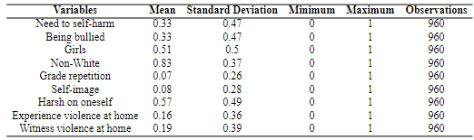

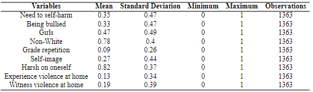

In the sample collected before the pandemic, 51.36% of students were female, while after the pandemic this percentage decreased to 47.37%. As for race, 83.02% of students declared themselves non-white before the pandemic, a percentage that decreased to 78.94% in the subsequent period.

## **Method**

To assess the relationship between bullying and self-harm, logistic regression models were estimated separately for each year in the sample (2019 and 2022). Specifically, the proposed model can be represented by the equation:

$$\begin{equation}
\label{eq:eq1}
Y_{it} = \beta_1 \textit{bullying}_{t-1} + \beta_2 X_{it} + \beta_3
W_{it-1} + \varepsilon_{it}
\end{equation}$$

An important limitation of this study is that it is not possible to control for unobservable characteristics. If the error term $\varepsilon_{it}$ is correlated with the variable of interest $\textit{bullying}_{it-1}$ the estimate of $\beta_1$ will be biased. Thus, the results presented in this paper should be interpreted only as correlations and not a causal effect.

# **Results**

According to the literature, the experience of bullying is associated with an increased risk of mental health problems and self-destructive behaviors, such as the ideation or practice of self-harm (KALLMEN; HALLGREN, 2021; AHMAD et al., 2023; AUGUSTINE et al., 2024; WANG et al., 2024). In the case of Sobral, both bullying and the ideation of self-harm are phenomena of high incidence in the period analyzed. In comparative terms, in the United States, approximately 19% of students aged 12 to 18 reported having been bullied during the 2021-2022 school year (National Center for Education Statistics, 2024b). Rates tend to peak in elementary school, especially for students in grades 6-9, where approximately 26% of elementary school students report having been bullied (National Center for Education Statistics, 2024a). Figure 1 shows that at least one-third of students in the sample have been victims of bullying, while a similar proportion reported having felt the need to self-harm.

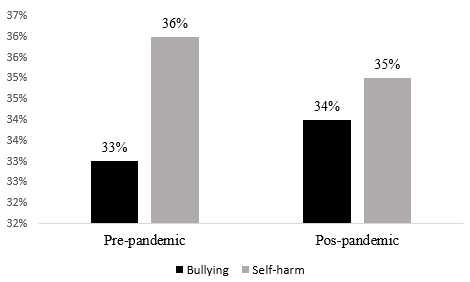

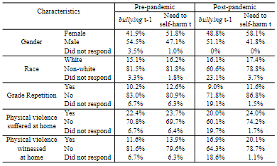

The incidence of bullying is slightly higher among boys, while the urge to self-harm is more prevalent among girls (both before and after social isolation). According to Gredler(2003), boys are generally more involved in bullying, both as victims and perpetrators. Social norms, especially those related to gender issues, can encourage aggressive and competitive behaviors among boys, making them more likely to experience physical and verbal bullying due to the pressure to conform to certain masculine stereotypes. On the other hand, girls tend to internalize their problems and negative emotions more, which can result in self-destructive behaviors such as self-harm (MUEHLENKAMP et al., 2012).

The incidence of bullying and the urge to self-harm is also higher among non-white students, which is not entirely surprising. Historically, these students are more exposed to racial bias, stereotypes, and discrimination and may respond differently to stress and psychological trauma (GALINA et al., 2017).

Table 4 presents the estimated odds ratios using the model defined by equation 1, before and after the pandemic. Columns (1) and (4) present the estimates without any control variables, while columns (2) and (5) include individual characteristics and columns (3) and (6) include variables that control for the students’ family environment.

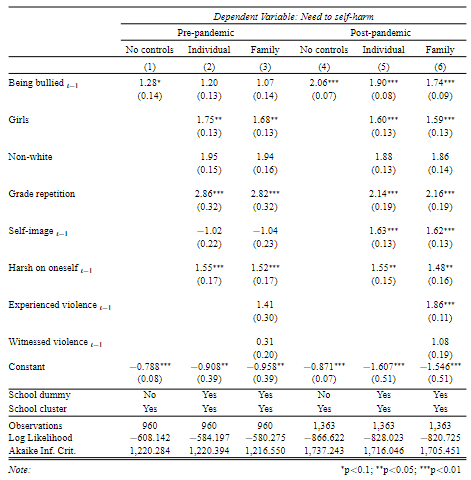

Other important factors to explain the probability of feeling the need to hurt oneself can be evaluated in Table 4. For example, girls are 68% more likely than boys, which is consistent with studies such as those by . After the pandemic, girls maintain this trend, with an approximately 59% greater chance of feeling the need to harm themselves compared to girls. Studies suggest that the pandemic has exacerbated risk factors for self-harm among girls, including increased social isolation, greater exposure to emotional stress, and anxiety .

Regarding school failure, the results indicate that, before the pandemic, individuals who repeated a grade were approximately 2.82 times more likely to feel the need to harm themselves compared to those who did not repeat a grade. After the pandemic, repetition remains the most significant predictor of the need to harm oneself, corroborating the influence of academic difficulties on mental health. Studies show that academic failure is related to an increase in psychological stress, combined with stigmatization in front of peers, contributing to the need to harm oneself as a way of dealing with the perception of inadequacy . Academic difficulties, amplified by the pandemic, have increased the pressure on students, making failure a significant predictor of self-harm, especially in contexts where there is a strong emphasis on academic performance, such as in Sobral. It is expected that failure has a significant weight in the pressures resulting from academic failure. In line with this, observe that students who have never failed a grade are more likely to exhibit prosocial behaviors.

With regard to self-criticism, individuals who are harder on themselves are 52% more likely to feel the need to harm themselves compared to those who are not as self-critical. Self-criticism is the tendency to evaluate oneself harshly and negatively. Individuals who are overly critical of themselves often face intense feelings of inadequacy and failure . These feelings contribute to self-injurious ideation as they increase emotional pain and feelings of hopelessness. In this case, the inclusion of family variables, such as having suffered or witnessed violence at home, reduces the magnitude of the relationship between self-criticism and self-harm, indicating that the family environment is an important moderator of this effect, so that the presence of violence seems to divert the focus of self-criticism, making its effects less pronounced when other family factors are at play. According to , family dynamics can create a context in which the effects of self-criticism are mitigated or eclipsed by the need to deal with more immediate and tangible traumas.

## **Heterogeneous Effects**